# Tarea 8 Estadística Multivariada

Hairo Ulises Miranda Belmonte

23 de Mayo del 2019

Este conjunto de datos fue estudiado por Madsen (1976) para las condiciones de alojamiento en areas seleccionadas de Copenhague, Dinamarca. Un total de 1; 681 residentes rentando en casas construidas durante el periodo de 1960-1968 fueron seleccionados para contestar una encuesta acerca de su nivel de satisfaccion (ca-tegorizado como bajo (ls), medio (ms), alto (hs)), el nivel de contacto con otros residen-tes (bajo (lc),alto (hc)), y su sensacion de inuencia sobre el manejo de su vivienda (bajo (li),medio (mi),alto (hi)). Las unidades de renta fueron categorizadas como towe blocks (tb),apartamentos (ap), atrium houses (ah) y casas con terraza (th). El proposito del estudio es identi car si existe algun asociacion entre el grado de contacto,inuencia, satisfaccion, y el tipo de vivienda. Aplique el Analisis de Correspondencia Multiple al archivo adjuto y explique las asociaciones principales de cada eje.

- Diga si existen asociaciones signi cativas entre los pares de variables categoricas al nivel de signi cancia de $0.05$.
- Explique y justi que el por que es posible reducir dimensión directamente sobre la tabla $( 1nQY )$ cuando naturalmente uno deberia de realizar el análisis sobre los bloques no diagonales de Y .

```r
library("tidyverse")
library("magrittr")
library("readxl")
library("knitr")
library("kableExtra")
library("ca")
library("FactoMineR"); library("factoextra")
getwd()
```

```
## [1] "C:/Users/h_air/Desktop/Tarea 8"
```

```r
setwd("C:/Users/h_air/Desktop/Tarea 8")
datos <- read.csv("ejemplo_mca.csv", header = F)

names(datos) <- c("tb","ap","ah","th","li","mi","hi","lc","hc","ls","ms","hs")
labels <- c("tb","ap","ah","th","li","mi","hi","lc","hc","ls","ms","hs")
datos <-cbind(labels, datos)
datos %>% column_to_rownames(var="labels")
```

```
##     tb  ap  ah  th  li  mi  hi  lc  hc  ls  ms  hs
## tb 400   0   0   0 140 172  88 219 181  99 101 200
## ap   0 765   0   0 268 297 200 317 448 271 192 302
## ah   0   0 239   0  95  84  60  82 157  64  79  96
## th   0   0   0 227 124 106  47  95 182 133  74  70
## li 140 268  95 124 627   0   0 234 393 282 170 175
## mi 172 297  84 106   0 659   0 279 380 206 189 264
## hi  88 200  60  47   0   0 395 200 195  79  87 229
## lc 219 317  82  95 234 279 200 713   0 262 178 273
## hc 181 448 157 182 393 380 195   0 968 305 268 395
## ls  99 271  64 133 282 206  79 262 305 567   0   0
## ms 101 192  79  74 170 189  87 178 268   0 446   0
## hs 200 302  96  70 175 264 229 273 395   0   0 668
```

## Ejercicio 1

```r
datos <- datos %>% column_to_rownames(var="labels")
nrow<-nrow(datos)
ncol<-ncol(datos)
n<-sum(datos)

#se calcula la chi cuadrada para probar la independencia de los renglones y columnas de la tabla de contingencia y la inercia total (medida de la
#variabilidad total de los datos en la tabla)

# Entre pares
chiTest <- function(X){
  chiR<-chisq.test(X)
  inetot<-chiR$statistic/n
  return(list(chi=chiR,Itot=inetot))
}
```

Se realizan las pruebas chi-cuadrada:

$H_0$ asume que no hay relación entre las varianles; i.e., una variable no varía respecto otras. $H_a$ indica que existe alguna especie de relación entre las variables.

Se prueba independencia de los renglones y columna de la tabla de contigencia de la relación $X_{12}$

```r
X12 <-datos[1:4,5:7]
X12crit <- chiTest(X12)
X12crit
```

```
## $chi
##
##  Pearson's Chi-squared test
##
## data:  X
## X-squared = 16.66, df = 6, p-value = 0.01062
##
##
## $Itot
##    X-squared
## 0.0006205744
```

Con un p valor menor al 0.05, se tiene evidencia para rechazar la $H_o$ de independencia, por lo tanto existe alguna especie de relación en $X_{12}$

```r
X13 <-datos[1:4,8:9]
X13crit <- chiTest(X13)
X13crit
```

```
## $chi
##
##  Pearson's Chi-squared test
##
## data:  X
## X-squared = 39.121, df = 3, p-value = 1.636e-08
##
##
## $Itot
##  X-squared
## 0.00145724
```

Con un p valor menor al 0.05, se tiene evidencia para rechazar la $H_o$ de independencia, por lo tanto existe alguna especie de relación en $X_{13}$

relación $X_{14}$

```r
X14 <-datos[1:4,10:12]
X14crit <- chiTest(X14)
X14crit
```

```
## $chi
##
##  Pearson's Chi-squared test
##
## data:  X
## X-squared = 60.286, df = 6, p-value = 3.937e-11
##
##
## $Itot
##   X-squared
## 0.002245621
```

Con un p valor menor al 0.05, se tiene evidencia para rechazar la $H_o$ de independencia, por lo tanto existe alguna especie de relación en $X_{14}$

relación $X_{23}$

```r
X23 <-datos[5:7,8:9]
X23crit <- chiTest(X23)
X23crit
```

```
## $chi
##
##  Pearson's Chi-squared test
##
## data:  X
## X-squared = 17.586, df = 2, p-value = 0.0001518
##
##
## $Itot
##    X-squared
## 0.0006550593
```

Con un p valor menor al 0.05, se tiene evidencia para rechazar la $H_o$ de independencia, por lo tanto existe alguna especie de relación en $X_{23}$

relación $X_{24}$

```r
X24 <-datos[5:7,10:12]
X24crit <- chiTest(X24)
X24crit
```

```
## $chi
##
##  Pearson's Chi-squared test
##
## data:  X
## X-squared = 106.18, df = 4, p-value < 2.2e-16
##
##
## $Itot
##   X-squared
## 0.003954968
```

Con un p valor menor al 0.05, se tiene evidencia para rechazar la $H_o$ de independencia, por lo tanto existe alguna especie de relación en $X_{24}$

relación $X_{34}$

```r
X34 <-datos[10:12,8:9]
X34crit <- chiTest(X34)
X34crit
```

```
## $chi
##
##  Pearson's Chi-squared test
##
## data:  X
## X-squared = 5.1398, df = 2, p-value = 0.07654
##
##
## $Itot
##    X-squared
## 0.0001914564
```

Con un p valor mayor al 0.05, no se tiene evidencia para rechazar la $H_o$ de independencia, por lo tanto no existe alguna especie de relación en $X_{34}$

## Ejercicio 2

Ahora se visualiza en dos dimensiones los punto de la matriz de Burt.

```r
# Se calcula la matriz F de frecuencias relativas o matriz de correspondencia

F_datos<-(datos)/n
#se calculan las frecuencias relativas de las filas y de las columnas de F  o tambien llamadas masas (las ri y las cj)
rtot<-(apply(datos,1,sum))/n
ctot<-apply(datos,2,sum)/n
# los vectores obtenidos se  colocan en las matrices diagonales correspondientes (Dr y Dc)
Dr<-diag(rtot)
Dc<-diag(ctot)
# se calcula la matriz de perfiles por fila (R)
table.pro<-datos/rtot  #matriz R de renglones
# se calcula la matriz de perfiles por columna (Rc)
table.pcol<- t(t(datos)/ctot)  #matriz R de columnas
#se calcula la chi cuadrada y la inercia total
t.rowsum<-n*rtot
t.colsum<-n*ctot
tabla_exp<-t.rowsum%o%t.colsum/n
chi2<- sum((datos-tabla_exp)^2/tabla_exp)
inetot<-chi2/n
#se calcula la matriz Z
Z <-(sqrt(solve(Dr)))%*%as.matrix(F_datos)%*%(sqrt(solve(Dc)))
#se obtienen los vectores propios y valores propios mediante la descomposicion en valores singulares de Z
dvalsing<-svd(Z )
#Se obtienen las representaciones de las filas y columnas en un espacio de dos dimensiones considerando los vectores propios ai y bi obtenidos de la dvs
#OJO:se consideran solo los vectores propios asociados a valores propios distintos de 1, en este caso se consideran las columnas 2 y 3 de las matrices U y V
#de la dvs.
ind<-c(2,3)
#Representacion de las filas en dos dimensiones
Cr<-(sqrt(solve(Dr)))%*%Z%*%dvalsing$v[,ind]
#Representacion de las columnas en dos dimensiones
Cc<-(sqrt(solve(Dc)))%*%t(Z)%*%dvalsing$u[,ind]
#se calcula la proporcion de la inercia explicada por las dos  dimensiones (asociadas a valores propios distintos de cero)
vp<-(dvalsing$d)^2
vp_dist1<-vp[-1]
vp_dist1
```

```
##  [1] 1.128255e-01 8.028738e-02 7.162263e-02 6.336631e-02 5.712751e-02
##  [6] 4.965323e-02 4.397618e-02 2.593644e-02 4.404882e-05 5.616135e-34
## [11] 5.530319e-35
```

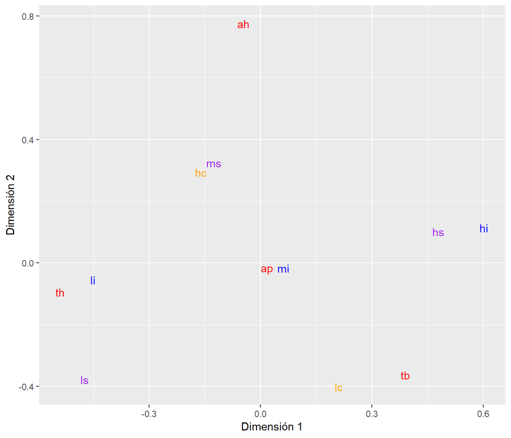

```r
var_expl <- sum(vp_dist1[1:2])/sum(vp_dist1)
# Se obtiene la representacion conjunta de los renglones y columnas en el espacio de dos dimensiones
uno <- rep("red", 4)
dos <- rep("blue", 3)
tres <- rep("orange", 2)
cuatro<- rep("purple", 3)
colores <- c(uno,dos,tres,cuatro)

#Se calculan las distancias chi cuadrada de cada renglon de R a su centroide: (Ra-c)'Dc^-1(Ra-c)
dist.chicua.ren<-sqrt(apply((t(table.pro)-ctot)^2/ctot,2,sum))

#se calcula la inercia de cada renglon, que se obtiene simplemente multiplicando las distancia chicuadrada a su centroide (al cuadrado) por su masa correspondiente
inercia.ren<-((dist.chicua.ren)^2) *rtot


#Se calculan las distancias chi cuadrada de cada columna de R a su centroide: (Ra-c)'Dr^-1(Ra-c)
dist.chicua.col<-sqrt(apply(((table.pcol)-rtot)^2/rtot,2,sum))

#se calcula la inercia de cada columna, que se obtiene simplemente multiplicando las distancia chicuadrada a su centroide (al cuadrado) por su masa correspondiente
inercia.col<-((dist.chicua.col)^2) *ctot


Cr %>% as.data.frame %>% ggplot() +
  aes(x=V1, y=V2,  label = rownames(datos)) +
  geom_text( col=colores) + labs(x="Dimensión 1", y="Dimensión 2")
```

Se observa que para el eje de la dimensión uno, estar representados por las variables casas con terraza (th), sensación de influencia sobre el manejo de su vivienda bajo (li) y alto (hi), satisfacción baja (ls) y alta (hs).

En el eje dos, puede estar representado por los residentes con unidades de renta categorizadas como atrium houses (ah), el nivel de contacto con otros residentes alto (hc) y nivel de satifacción medio (ms).

Donde los residente con casa con terraza (th) se relacionan con la sensación del manejo de su vivienda baja (li) y reportan nivel de satisfacción baja (li). Por otro lado, los residentes con manejo de vida alto (hi), se relacionan con aquellos que reportaron un nivel de satisfacción alto (hs).

## Ejercicio 3

Explicando el porque se puede realizar la reducción de dimensiones con la matrix Burt.

Por la simétria de la matriz de Burt, un análisis de correspondencia simple en ella produce el mismo conjunto de coordenadas filas y columnas, así que uno de los dos conjuntos pueden ser ignorados; asimismo, las filas estándar de las filas de la matriz de Burt son identicas a las coordenadas estándar de las filas de $Z$, la matriz con la que trabajamos para obtener la reducción de dimensiones, de esta fomra las principales coordenadas obtenidas al análizar la matriz de Burt está directamente relacionadas a las obtenidas con $Z$, porque las inercias principales de la matriz de Burt son el cuadrado de las $Z$.